# Tutorial 3: Quantitative Image Processing

© 2017 Griffin Chure. This work is licensed under a [Creative Commons Attribution License CC-BY 4.0](https://creativecommons.org/licenses/by/4.0/). All code contained herein is licensed under an [MIT license](https://opensource.org/licenses/MIT)

```python
import numpy as np
import matplotlib.pyplot as plt
import seaborn as sns

# Utilities for image processing
import skimage.io
import skimage.filters
import skimage.exposure
import skimage.measure
import skimage.morphology
import skimage.segmentation

%matplotlib inline
```

## What are we after?

In class, we showed how we can use some priciples of statistical mechanics to generate a model for the regulation of a gene by a repressor protein. In brief, we arrived at an equation for the fold-change in gene expression which takes the form

$$ \text{fold-change} = \left(1 + {R \over N_{NS}}e^{-\beta\Delta\varepsilon_R}\right)^{-1} $$

[figure not shown]

## Images are data

```python
# Load the phase contrast image
phase_im = skimage.io.imread('data/lacI_titration/O1_delta_phase_pos_04.tif')
```

```python
# Look at the phase_im array
phase_im
```

```
array([[6539, 6108, 5913, ..., 5921, 5903, 5787],
       [5875, 5875, 5875, ..., 5903, 5808, 5787],
       [5494, 5494, 5556, ..., 5903, 5817, 5817],
       ...,
       [5633, 5467, 5467, ..., 5579, 5347, 5347],
       [5467, 5292, 5292, ..., 5614, 5938, 6077],
       [5292, 5292, 5292, ..., 5614, 6077, 6077]], dtype=uint16)
```

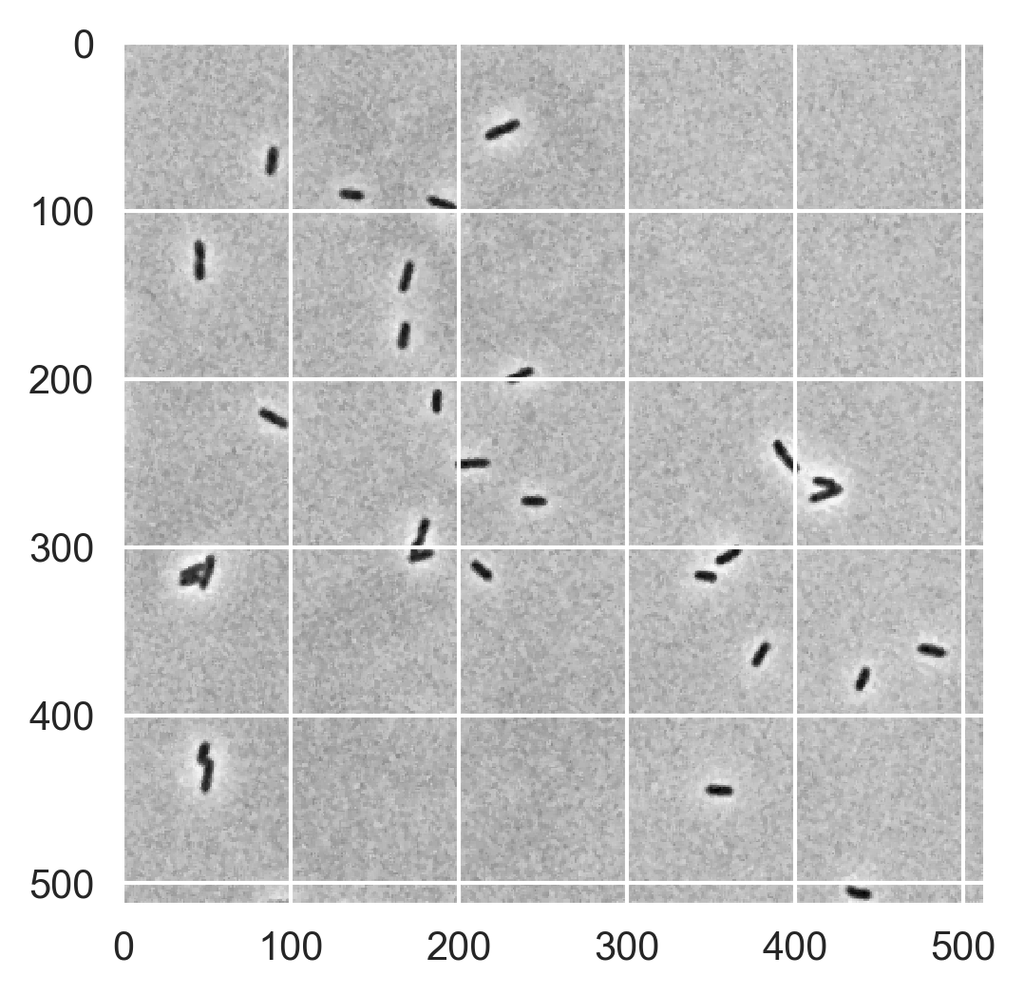

```python
# Set the colormap for data display.
gray = plt.cm.Greys_r

# Show the image
plt.imshow(phase_im, cmap=gray)
```

## Segmentation - Where are the bugs?

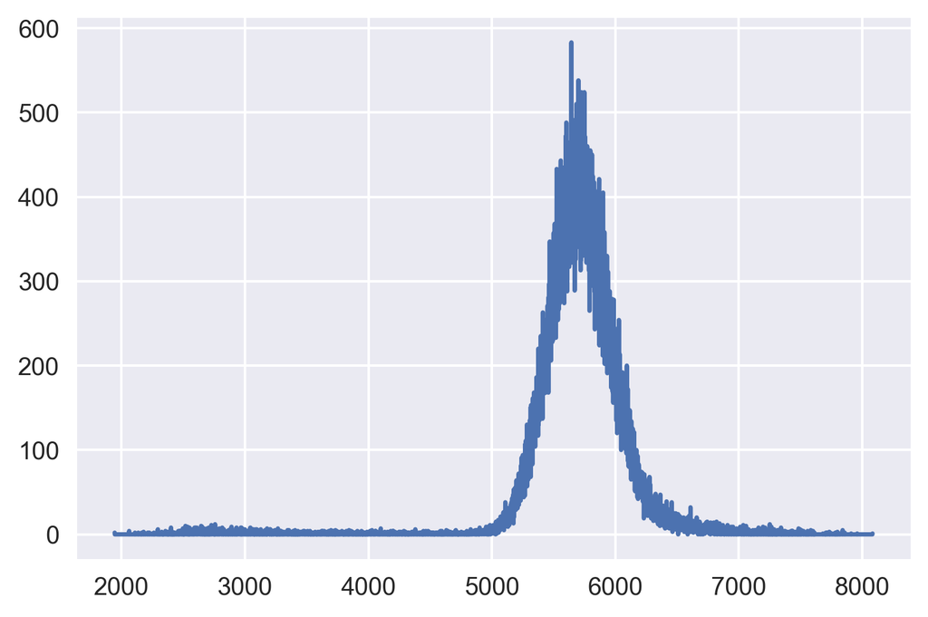

```python
hist, bins = skimage.exposure.histogram(phase_im)
plt.plot(bins, hist)
```

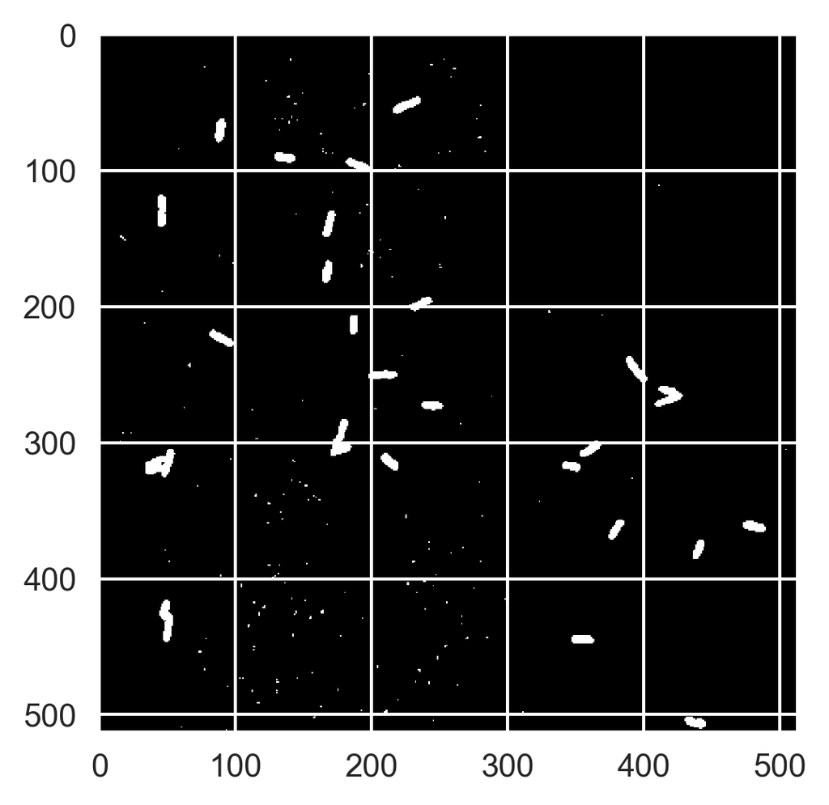

```python
# Threshold the image showing pixels only below 1000
thresh_im = phase_im < 5000
plt.imshow(thresh_im, cmap=gray)
```

That looks pretty good! Let's try applying this to another image to see if our threshold value is robust.

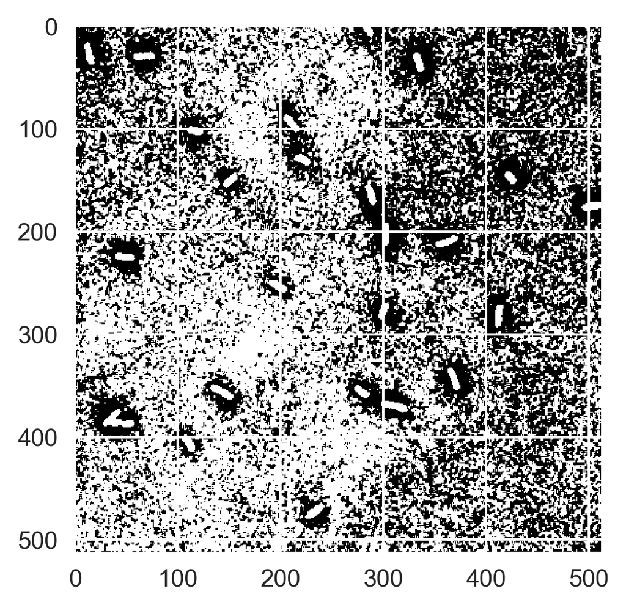

```python
# Load another phase contrast image.
phase_im2 = skimage.io.imread('data/lacI_titration/O1_auto_phase_pos_05.tif')

# Apply the threshold value of 1000 counts.
thresh_im2 = phase_im2 < 5000
plt.imshow(thresh_im2, cmap=gray)
```

It looks like with this threshold value, we segment the cells, but also a bunch of stuff in the background! It appears that there are differences in the distribution of pixel values between these two images. To check this, let's take a look at the histogram of each image overlaid with eachother.

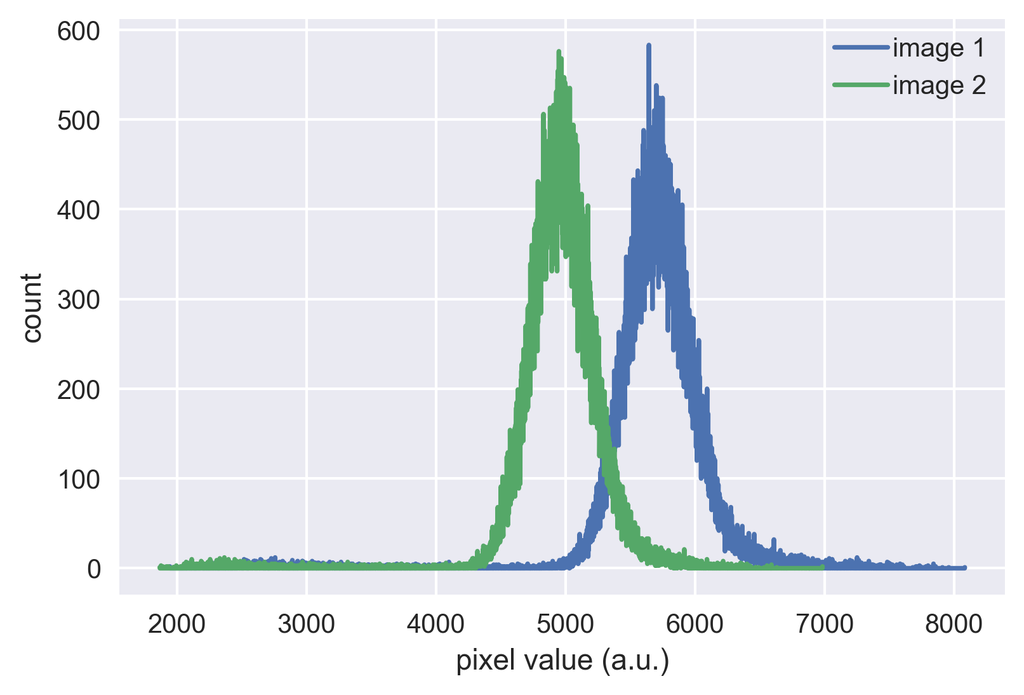

```python
# Generate the histograms for each image.
hist_im1, bins_im1 = skimage.exposure.histogram(phase_im)
hist_im2, bins_im2 = skimage.exposure.histogram(phase_im2)

# Each histogram over eachother.
plt.plot(bins_im1, hist_im1, label='image 1')
plt.plot(bins_im2, hist_im2, label='image 2')
plt.xlabel('pixel value (a.u.)')
plt.ylabel('count')
plt.legend()
```

$$ I_\text{norm} = {I - I_\text{min} \over I_\text{max} - I_\text{min}} \tag{x} $$

where $I$ is the original image, $I_\text{min}$ is the minimum value of the image, and $I_\text{max}$ is the maximum value. Let's write a function that will do this normalization for any image we provide.

```python
def normalize_im(im):
    """
    Normalizes a given image such that the values range between 0 and 1.
    """
    im_norm = (im - im.min()) / (im.max() - im.min())
    return im_norm
```

Let's test it out on our images and look at both histograms.

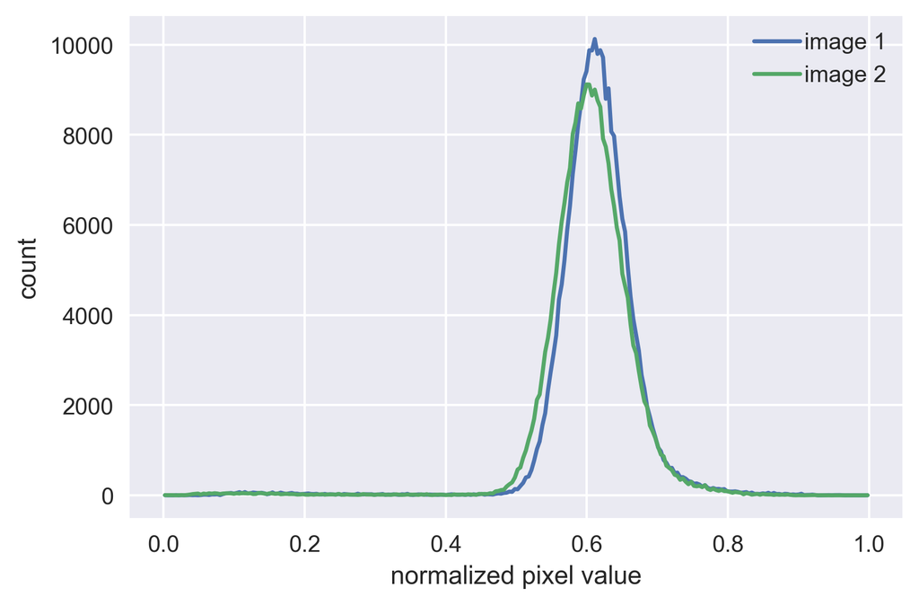

```python
# Normalize both images.
phase_norm1 = normalize_im(phase_im)
phase_norm2 = normalize_im(phase_im2)

# Generate both histograms.
hist_norm1, bins_norm1 = skimage.exposure.histogram(phase_norm1)
hist_norm2, bins_norm2 = skimage.exposure.histogram(phase_norm2)

# Plot both histograms on the same set of axes.
plt.plot(bins_norm1, hist_norm1, label='image 1')
plt.plot(bins_norm2, hist_norm2, label='image 2')

# Add labels as expected.
plt.xlabel('normalized pixel value')
plt.ylabel('count')
plt.legend()
```

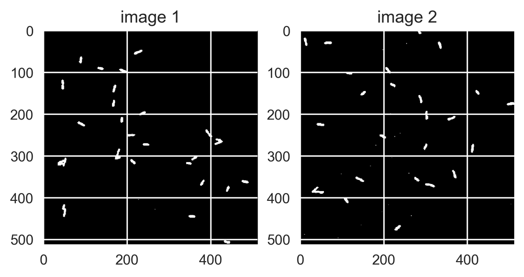

```python
# Apply the threshold.
thresh_val = 0.45
thresh_im1 = phase_norm1 < thresh_val
thresh_im2 = phase_norm2 < thresh_val

# Set up the axes for plotting.
fig, ax = plt.subplots(nrows=1, ncols=2)
ax[0].imshow(thresh_im1, cmap=gray)
ax[0].set_title('image 1')
ax[1].imshow(thresh_im2, cmap=gray)
ax[1].set_title('image 2')
```

Both images look comparable, but are they segmenting all of the bacterial cells in each image? To test how well our segmentation is working, we can merge our segmentation mask along with the normalized image and generate an RGB representation. Let's do this for each image and see how well we've done.

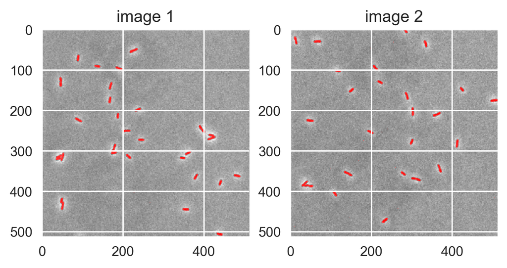

```python
# Make copies of each normalized phase image.
phase_copy1 = np.copy(phase_norm1)
phase_copy2 = np.copy(phase_norm2)

# Using the segmentation masks, color the pixels with a value of 1.0 wherever a
# segmented object exists.
phase_copy1[thresh_im1] = 1.0
phase_copy2[thresh_im2] = 1.0

# Make an RGB image of the segmentation by generating a three dimensional array.
rgb_image1 = np.dstack((phase_copy1, phase_norm1, phase_norm1))
rgb_image2 = np.dstack((phase_copy2, phase_norm2, phase_norm2))

# Show both images again using a subplot. Since these are RGB, we won't need to
# use a colormap.
fig, ax = plt.subplots(nrows=1, ncols=2)
ax[0].imshow(rgb_image1)
ax[0].set_title('image 1')
ax[1].imshow(rgb_image2)
ax[1].set_title('image 2')
```

It looks like we've done a really great job! However, we want to take a look at the *single cell intensities*, but it looks like we've segmented clusters of cells as a single object. Furthermore, we've only managed to identify where bacteria are, but we have no way of identifying one object from another. In the next step of our pipeline, we'll individually label each cell and figure out how to separate what's worth keeping and what should be tossed.

## Filtering - Which bugs to we keep?

```python
# Label each individual cell.
im_lab, num_obj = skimage.measure.label(thresh_im1, return_num=True)

# Print out how many we identified. By eye, we expect around 26.
print("Number of objects found: %s" %num_obj)
```

```
Number of objects found: 27
```

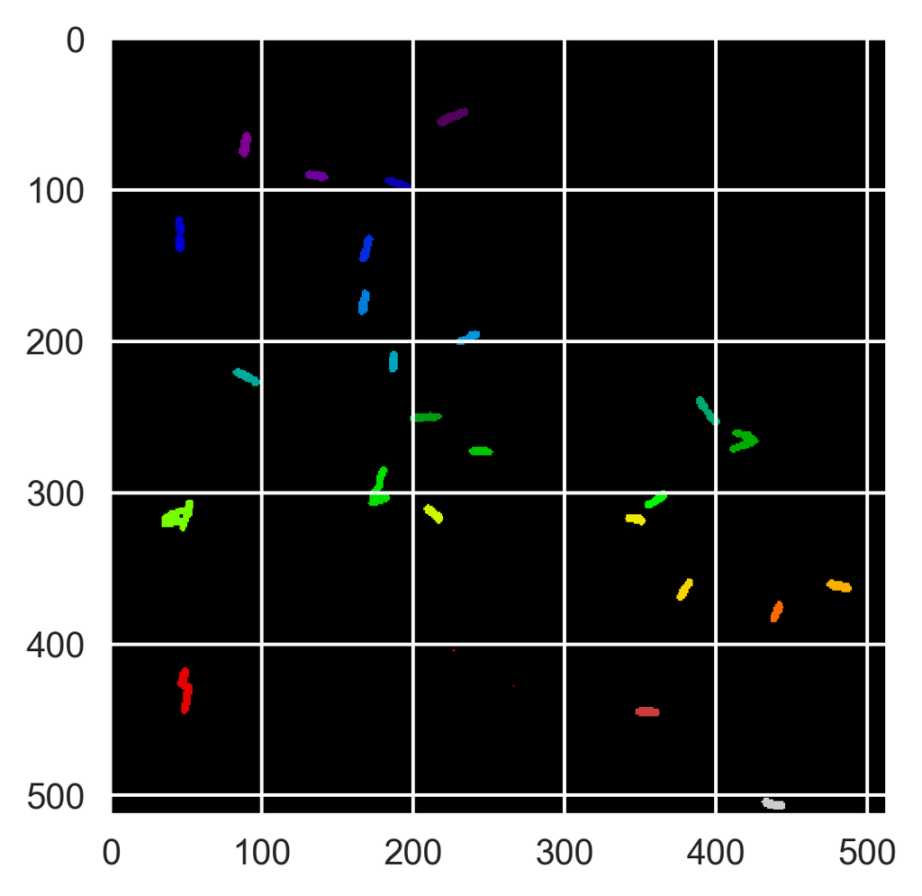

```python
# Show our labeled objects using a a different color map than gray.
rainbow = plt.cm.spectral
plt.imshow(im_lab, cmap=rainbow)
```

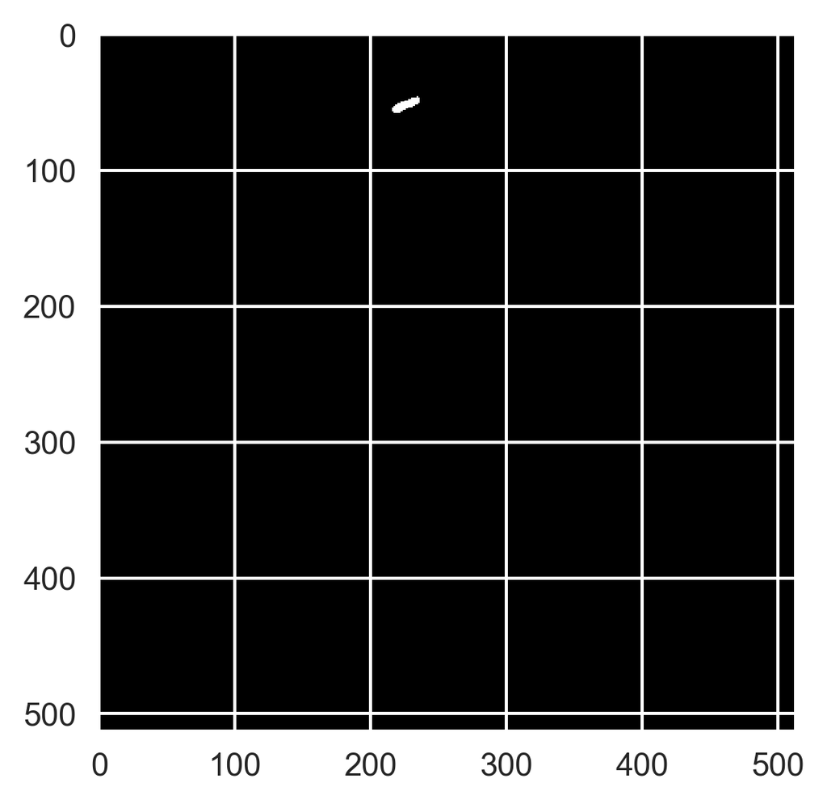

```python
# Look at a single bacerium
cell_id = 1
single_cell = im_lab==cell_id
plt.imshow(single_cell, cmap=gray)
```

It's important to note at this point, the **cells are labeled beginning from `1`!** Indexing at `0` will give you the background pixels!

```python
single_cell
```

```
array([[False, False, False, ..., False, False, False],
       [False, False, False, ..., False, False, False],
       [False, False, False, ..., False, False, False],
       ...,
       [False, False, False, ..., False, False, False],
       [False, False, False, ..., False, False, False],
       [False, False, False, ..., False, False, False]], dtype=bool)
```

Note that the `dtype` of this image is now a `bool`, meaning every pixel is either part of our labeled bacerium (`True` or `1`) or not (`False` or `0`). This means to get the projected area of our cell, we simply have to sum up the image.

```python
cell_pix = np.sum(single_cell)
print("The area of our single cell is %s pixels." %cell_pix)
```

```
The area of our single cell is 119 pixels.
```

How big is a typical bacterium? We know that the standard laboratory *E. coli* strain is around 1 - 2µm in length by 1µm in diameter. But how many pixels is that? To do this, we need to have some information about the interpixel distance of this particular camera. While we could figure this out using some image processing and some images of a stage micrometer, I know from my experience that this camera has an interpixel distance of 160 nm per pixel.

```python
# Convert pixels to physical units.
ip_dist = 0.160  # In units of microns per pixel.
cell_area = cell_pix * ip_dist**2
print("The area of our single cell is %s square microns." %cell_area)
```

```
The area of our single cell is 3.0464 square microns.
```

This measurement falls very close to what we expect of our "typical" *E. coli* cell. Let's determine the size of all of the *E. coli* cells in this particular image by looping this procedure over each labeled object.

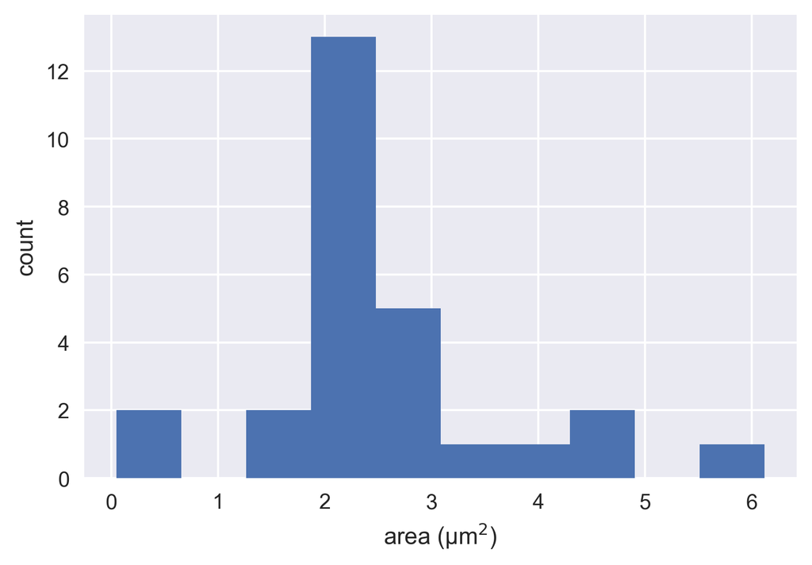

```python
# Make an array where we'll store the cell areas.
areas = np.zeros(num_obj)

# Loop through each object. Remember that we have to start indexing at 1 in
# this case!
for i in range(num_obj):
    # Slice out the cell of interest.
    cell = (im_lab == i + 1)

    # Compute the area and add it to our array
    areas[i] = np.sum(cell) * ip_dist**2


# Plot a histogram of our areas.
plt.hist(areas, bins=10)
plt.xlabel('area (µm$^2$)')
plt.ylabel('count')
```

That looks pretty good! We have few segmented objects that are a bit too big, hovering around 4.0 to 5.0 µm$^2$. These are likely the few clumps that we have.

Now that we have our hands on a parameter that will allow us to distinguish single cells, let's generate a new segmentation masks ignoring any object with an area greater than 4 µm$^2$ and anything less than 1µm^2. We can do this making a blank image and adding only the labels that meet our criterion to this blank image.

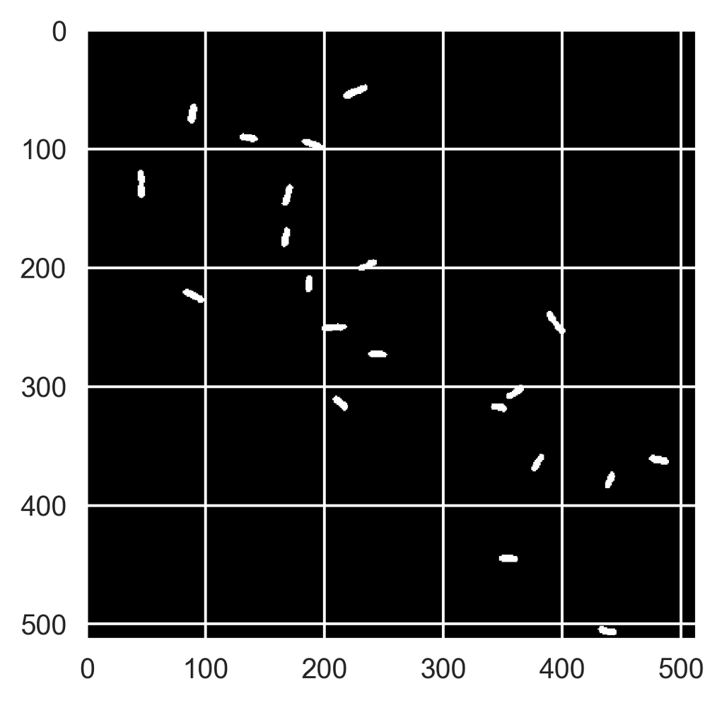

```python
# Make a copy of our binary image
approved_cells = np.zeros_like(thresh_im1)

# Loop through each object and test its area.
for i in range(num_obj):
    # Get the cell of interest.
    cell = (im_lab == i + 1)

    # Compute its area.
    cell_area = np.sum(cell) * ip_dist**2

    # Test if it is within our bounds.
    if (cell_area > 1.0) & (cell_area < 4.0):

        # Add our extraced cell to our blank image.
        approved_cells += cell

# Now let's show our new segmentation mask.
plt.imshow(approved_cells, cmap=gray)
```

That looks pretty good! Note that our segmentation mask has now been reverted back to a binary image. Let's relabel this image an also make an RGB image showing our final segmentation mask.

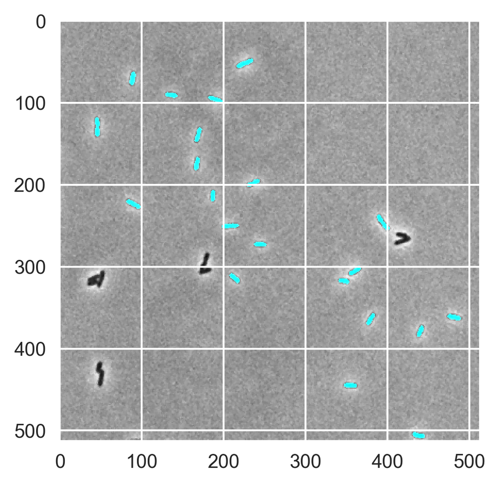

```python
# Relabel the image.
approved_lab, approved_obj = skimage.measure.label(approved_cells,
                                                   return_num=True)

# Make a copy of the normalized phase image.
phase_copy = np.copy(phase_norm1)

# Give the segmented pixels a value of 1.0
phase_copy[approved_cells] = 1.0

# Make an RGB image and show it. This time, we'll make them cyan.
mask_rgb = np.dstack((phase_norm1, phase_copy, phase_copy))

# Show it off!
plt.imshow(mask_rgb)
```

## Measurement - How bright are the bugs?

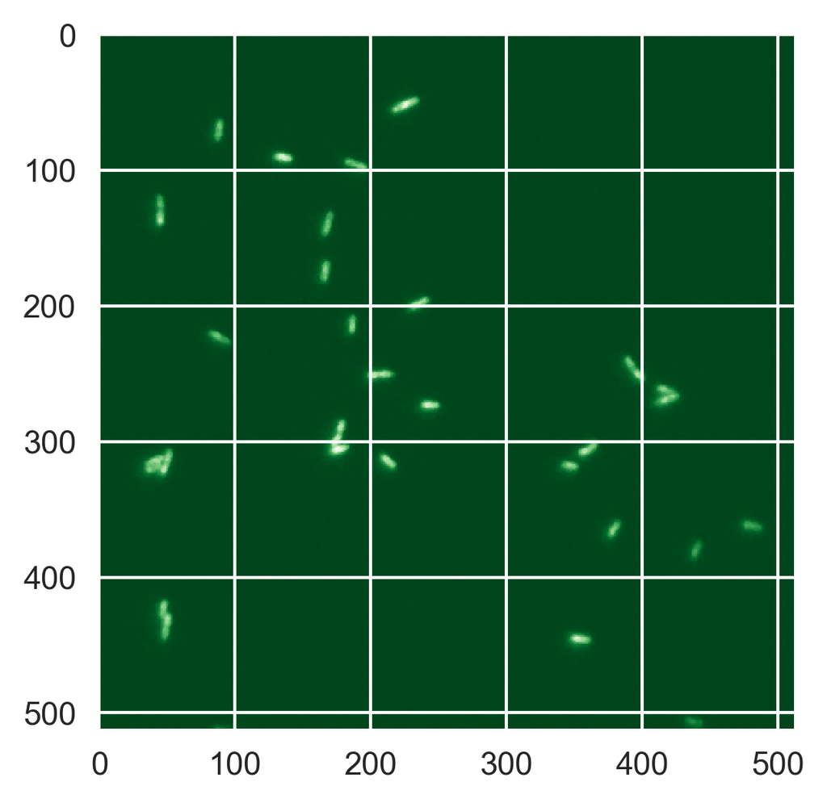

```python
# Load the fluorescence image for this poisition.
yfp_im = skimage.io.imread('data/lacI_titration/O1_delta_yfp_pos_04.tif')

# Show it with a green colormap.
green = plt.cm.Greens_r
plt.imshow(yfp_im, cmap=green)
```

Using our labeled segmentation mask, we would like to measure the total fluorescence of each individual cell. By multiplying one indexed cell at a time with the fluorescence image, we can extract the pixel intensity values for each individual cell. Let's try this by looking at cell number 6.

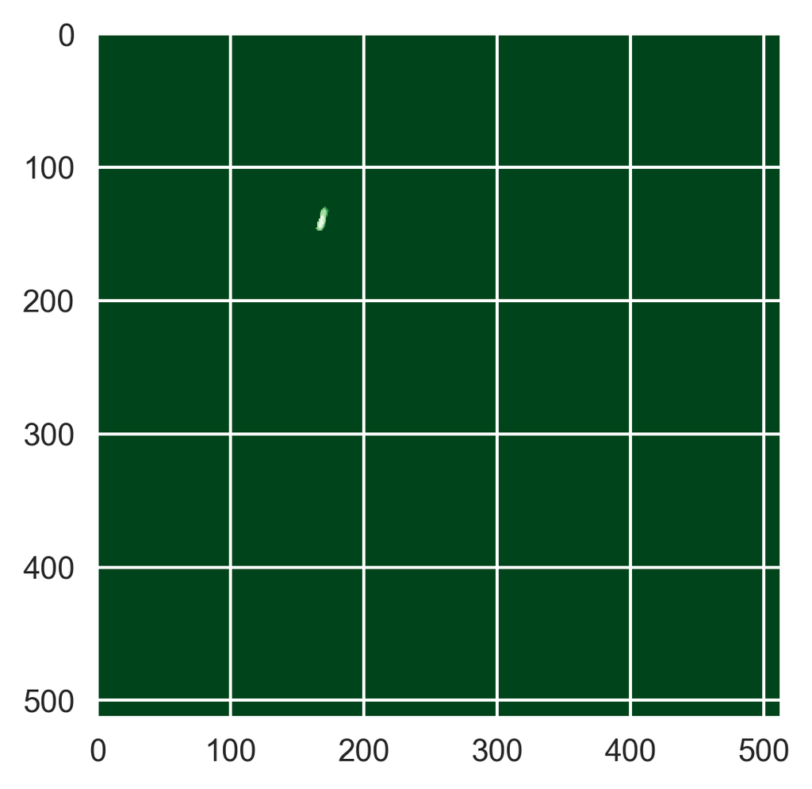

```python
# Look at the intensity image only for cell 10.
cell_id = 6
cell = (approved_lab == cell_id)

# Multiply the images.
cell_yfp = cell * yfp_im

# Show the multiplication.
plt.imshow(cell_yfp, cmap=green)
```

Now that we have this multiplication, we can simply sum the image to get the total intensity of that cell.

```python
# Get the total cell intensity.
total_int = np.sum(cell_yfp)
print('The total intensity of cell number 5 is %s counts.' %total_int)
```

```
The total intensity of cell number 5 is 189728 counts.
```

Let's repeat this procedure over all of the cells in this image and show a histogram.

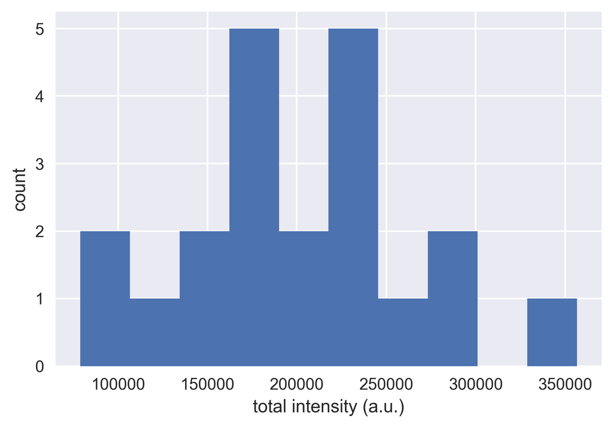

```python
# Set up storage vectors for the cell areas and intensities
tot_ints = np.zeros(approved_obj)

# Loop through each cell.
for i in range(approved_obj):

    # Get the single cell mask.
    cell = (approved_lab == i + 1)

    # Multiply it with the fluorescence image.
    int_im = cell * yfp_im

    # Store the total intensity
    tot_ints[i] = np.sum(int_im)

# Plot the histogram.
plt.hist(tot_ints, bins=10)
plt.xlabel('total intensity (a.u.)')
plt.ylabel('count')
```